# Vignette: Weighted BACON algorithms

Tobias Schoch

## Introduction

The package `wbacon` implements a weighted variant of the BACON (blocked adaptive computationally-efficient outlier nominators) algorithms Billor et al. (2000) for multivariate outlier detection and robust linear regression. The extension of the BACON algorithm for outlier detection to allow for weighting is due to Béguin and Hulliger (2008).

### Available methods

- `wBACON()` is for multivariate outlier nomination and robust estimation of location/ center and covariance matrix
- `wBACON_reg()` is for robust linear regression (the method is robust against outliers in the response variable and the model’s design matrix)

### Assumptions

The BACON algorithms assume that the underlying model is an appropriate description of the non-outlying observations; Billor et al. (2000). More precisely,

- the outlier nomination method assumes that the “good” data have (roughly) an *elliptically contoured* distribution (this includes the Gaussian distribution as a special case);
- the regression method assumes that the non-outlying (“good”) data are described by a *linear* (homoscedastic) regression model and that the independent variables (having removed the regression intercept/constant, if there is a constant) follow (roughly) an elliptically contoured distribution.

*“Although the algorithms will often do something reasonable even when these assumptions are violated, it is hard to say what the results mean.”* Billor et al. (2000, p. 290)

It is strongly recommended that the structure of the data be examined and whether the assumptions made about the “good” observations are reasonable.

### The role of the data analyst

In line with Billor et al. (2000, p. 290), we use the term outlier “nomination” rather than “detection” to highlight that algorithms should not go beyond nominating observations as *potential* outliers; see also Béguin and Hulliger (2008). It is left to the analyst to finally label outlying observations as such.

The software provides the analyst with tools and measures to study potentially outlying observations. It is strongly recommended to use the tools.

### Additional information

Additional information on the BACON algorithms and the implementation can be found in the documents:

- `methods.pdf`: A mathematical description of the algorithms and their implementation;
- `doc_c_functions.pdf`: A documentation of the `C` functions.

Both documents can be found in the package folder `doc`.

## Installation

Make sure that the package `devtools` is installed.<sup>1</sup> Then, the `wbacon` package can be pulled and installed from the [GitHub](https://github.com/tobiasschoch/wbacon) repository using

```r
> devtools::install_github("tobiasschoch/wbacon")
```

The package contains `C` code that needs to be compiled. Users of Microsoft Windows need an installation of the R tool chain bundle [rtools40](https://cran.r-project.org/bin/windows/Rtools/) to build the package.

Once the package has been installed, it can be loaded and attached to the current R session by

```r
> library(wbacon)
```

## Multivariate outlier detection

In this section, we study multivariate outlier detection for the two datasets

- bushfire data (with sampling weights),
- philips data (without sampling weights).

### Bushfire data

#### Data preparation

The bushfire data contain radiometer readings for 38 pixels and have been studied in Maronna and Yohai (1995), Béguin and Hulliger (2002), Béguin and Hulliger (2008), and Hulliger and Schoch (2009). The data can be obtained from the `R` package `modi`(Hulliger and Sterchi, 2020).<sup>2</sup>

```r
> data(bushfire, package = "modi")
```

The first 6 readings on the five frequency bands (variables) are

```r
> head(bushfire)
   X1  X2  X3  X4  X5
1 111 145 188 190 260
2 113 147 187 190 259
3 113 150 195 192 259
4 110 147 211 195 262
5 101 136 240 200 266
6  93 125 262 203 271
```

Béguin and Hulliger (2008) generated a set of sampling weights. The weights can be attached to the current session by

```r
> data(bushfire.weights, package = "modi")
```

#### Outlier detection

```r
> fit <- wBACON(bushfire, w = bushfire.weights, alpha = 0.05)
> fit

Weighted BACON: Robust location, covariance, and distances
Converged in 3 iterations (alpha = 0.05)
Number of potential outliers: 13 (34.21%)
```

The argument `alpha` determines the $(1-\alpha)$-quantile $\chi_{\alpha,d}^2$ of the chi-square distribution with $d$ degrees of freedom.<sup>3</sup> All observations whose squared Mahalanobis distances are smaller than the quantile (times a correction factor) are selected into the subset of outlier-free data. It is recommended to choose `alpha` on grounds of an educated guess of the share of “good” observations in the data. Here, we suppose that 95% of the observations are not outliers.

By default, the initial subset is determined by the Euclidean norm (initialization method: `version = "V2"`).

- This initialization method is robust because it is based on the coordinate-wise (weighted) median. The resulting estimators of center and scatter are *not affine equivariant*. Let $T(\cdot)$ denote an estimator of a parameter of interest (e.g., covariance matrix) and let $X$ denote the $(n \times p)$ data matrix. An estimator $T$ is affine equivariant if and only if $T(A X + b) = A T(X) + b$, for any nonsingular $(m \times n)$ matrix $A$ and any $n$-vector $b$. Although version `"V2"` of the BACON method yields an estimator that is not affine equivariant in the above sense, Billor et al. (2000) point out that the method is nearly affine equivariant.
- There exists an alternative initialization method (`"version = V1"`) which is based on the coordinate-wise (weighted) means; therefore, it is affine equivariant but *not robust*.

From the above output, we see that the algorithm converged in three iterations. In case the algorithm does not converge, we may increase the maximum number of iterations (default: `maxiter = 50`) and toggle `verbose = TRUE` to (hopefully) learn more why the method did not converge.

In the next step, we want to study the result in more detail. In particular, we are interested in the estimated center and scatter (or covariance) matrix. To this end, we can call the `summary()` method on the object `fit`.

```r
> summary(fit)

Weighted BACON: Robust location, covariance, and distances
Initialized by method: V2
Converged in 3 iterations (alpha = 0.05)

Number of potential outliers: 13 (34.21%)

Robust estimate of location:
   X1    X2    X3    X4    X5
108.4 149.0 275.6 218.7 279.8

Robust estimate of covariance:
        X1     X2      X3     X4     X5
X1   397.3  301.4 -1368.2 -268.1 -227.0
X2   301.4  258.9  -916.2 -161.3 -143.2
X3 -1368.2 -916.2  7262.8 1757.8 1406.6
X4  -268.1 -161.3  1757.8  472.2  368.5
X5  -227.0 -143.2  1406.6  368.5  290.4

Distances (cutoff: 5.675):
   Min. 1st Qu.  Median    Mean 3rd Qu.    Max.
  1.321   1.923   2.534   6.957  13.082  20.550
```

#### Diagnostics

The method has detected 13 *potential* outliers. It is important to study the diagnostic plot to learn more about the potential outliers. The robust (Mahalanobis) distances vs. the index of the observations (`1:n`) can be plotted as follows.

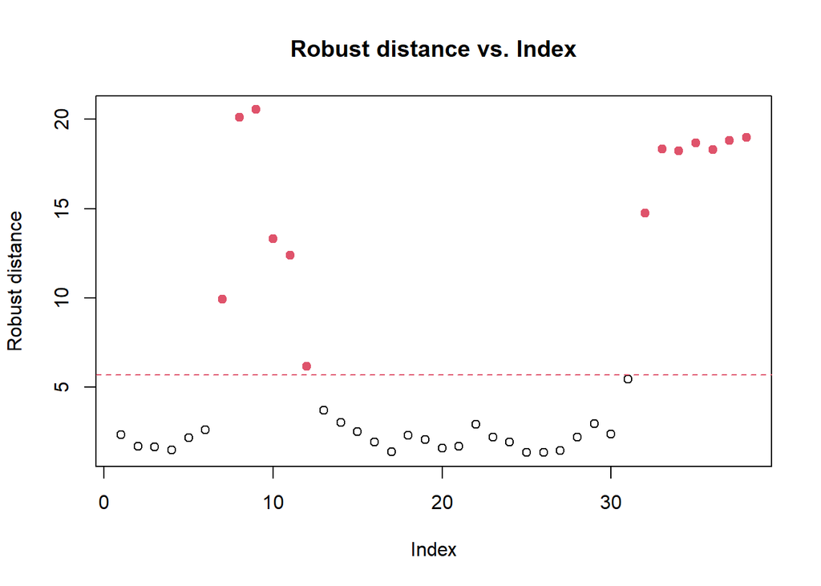

```r
> plot(fit, 1)
```

The dashed horizontal line shows the cutoff threshold on the robust distances. Observations above the line are nominated as potential outliers by the BACON algorithm. It is left to the analyst to finally label outlying observations as such. In the next section, we introduce an alternative plotting method (see below).

The method `is_outlier()` returns a vector of logicals whether an observation has been flagged as a potential outlier.

```r
> which(is_outlier(fit))
 [1]  7  8  9 10 11 12 32 33 34 35 36 37 38
```

The (robust) center and covariance (scatter) matrix can be extracted with the auxiliary functions, respectively, `center()` and `cov()`.

```r
> center(fit)
      X1       X2       X3       X4       X5
108.4462 148.9538 275.5692 218.6769 279.7538
```

The robust Mahalanobis distances can be extracted with the `distance()` method.